# Day 4 (AM): Data Visualization with ggplot2

SC INBRE Biostatistics Summer Intensive 2026

Published

August 6, 2026

# 1 Overview

By the end of this session you will be able to:

- Describe the grammar of graphics and how `ggplot2` implements it
- Choose the right geom for the data and question at hand
- Visualize distributions, relationships, and group comparisons
- Use `labs()`, `theme()`, scales, and facets to produce publication-ready figures
- Annotate plots and save them to disk with `ggsave()`

We use two datasets throughout: the **Framingham Heart Study** (which you already know) and the built-in `mpg` and `diamonds` datasets for some general plotting concepts.

# 2 The Grammar of Graphics

`ggplot2` is built on the idea that every plot can be described by the same small set of components:

| Component | What it controls |
| --- | --- |
| **Data** | The tibble you are visualizing |
| **Aesthetics** (`aes()`) | How variables map to visual properties (x, y, color, size, shape) |
| **Geoms** | The geometric objects that represent the data (points, lines, bars, boxes) |
| **Scales** | How data values map to aesthetic values (axis limits, color palettes) |
| **Facets** | Splitting the plot into small multiples by a grouping variable |
| **Theme** | Non-data appearance (fonts, background, grid lines) |

Every `ggplot2` plot follows the same template:

```r
ggplot(data = <DATA>) +
  <GEOM>(mapping = aes(<MAPPINGS>)) +
  <SCALES> +
  <FACETS> +
  <THEME>
```

# 3 Exploratory Data Analysis: Two Fundamental Questions

Exploratory data analysis (EDA) is the practice of systematically examining your data before modeling. Two questions drive EDA:

1. **What is the variation within each variable?** What is the typical value? How spread out are the values? Are there outliers?
2. **What is the covariation between variables?** How do two or more variables move together?

Your choice of plot depends on the types of variables involved:

| Variables | Plot type |
| --- | --- |
| 1 continuous | Histogram, density, boxplot |
| 1 categorical | Bar chart |
| 1 continuous + 1 categorical | Boxplot, violin, frequency polygon |
| 2 continuous | Scatterplot, smoothed line, 2D bin |
| 2 categorical | Mosaic, count heatmap |

```r
library(tidyverse)
library(this.path)
setwd(this.dir())

framingham <- read_csv("../../data/framingham.csv") |>
  mutate(
    male          = factor(male,          levels = c(0,1), labels = c("Female","Male")),
    currentSmoker = factor(currentSmoker, levels = c(0,1), labels = c("Non-smoker","Smoker")),
    prevalentHyp  = factor(prevalentHyp,  levels = c(0,1), labels = c("No","Yes")),
    diabetes      = factor(diabetes,      levels = c(0,1), labels = c("No","Yes")),
    TenYearCHD    = factor(TenYearCHD,    levels = c(0,1), labels = c("No","Yes")),
    education     = factor(education,     levels = 1:4,
                           labels = c("Some HS","HS Diploma","Some College","College Degree"))
  )
str(framingham)
```

```
tibble [4,240 × 16] (S3: tbl_df/tbl/data.frame)
 $ male           : Factor w/ 2 levels "Female","Male": 2 1 2 1 1 1 1 1 2 2 ...
 $ age            : num [1:4240] 39 46 48 61 46 43 63 45 52 43 ...
 $ education      : Factor w/ 4 levels "Some HS","HS Diploma",..: 4 2 1 3 3 2 1 2 1 1 ...
 $ currentSmoker  : Factor w/ 2 levels "Non-smoker","Smoker": 1 1 2 2 2 1 1 2 1 2 ...
 $ cigsPerDay     : num [1:4240] 0 0 20 30 23 0 0 20 0 30 ...
 $ BPMeds         : num [1:4240] 0 0 0 0 0 0 0 0 0 0 ...
 $ prevalentStroke: num [1:4240] 0 0 0 0 0 0 0 0 0 0 ...
 $ prevalentHyp   : Factor w/ 2 levels "No","Yes": 1 1 1 2 1 2 1 1 2 2 ...
 $ diabetes       : Factor w/ 2 levels "No","Yes": 1 1 1 1 1 1 1 1 1 1 ...
 $ totChol        : num [1:4240] 195 250 245 225 285 228 205 313 260 225 ...
 $ sysBP          : num [1:4240] 106 121 128 150 130 ...
 $ diaBP          : num [1:4240] 70 81 80 95 84 110 71 71 89 107 ...
 $ BMI            : num [1:4240] 27 28.7 25.3 28.6 23.1 ...
 $ heartRate      : num [1:4240] 80 95 75 65 85 77 60 79 76 93 ...
 $ glucose        : num [1:4240] 77 76 70 103 85 99 85 78 79 88 ...
 $ TenYearCHD     : Factor w/ 2 levels "No","Yes": 1 1 1 2 1 1 2 1 1 1 ...
```

# 4 Visualizing Distributions

## 4.1 Continuous Variables: Histograms

A histogram bins a continuous variable and counts observations per bin. Always try several `binwidth` values — the pattern can change substantially.

First, we’ll use the default binwidth value, which ends up being 8 (I think):

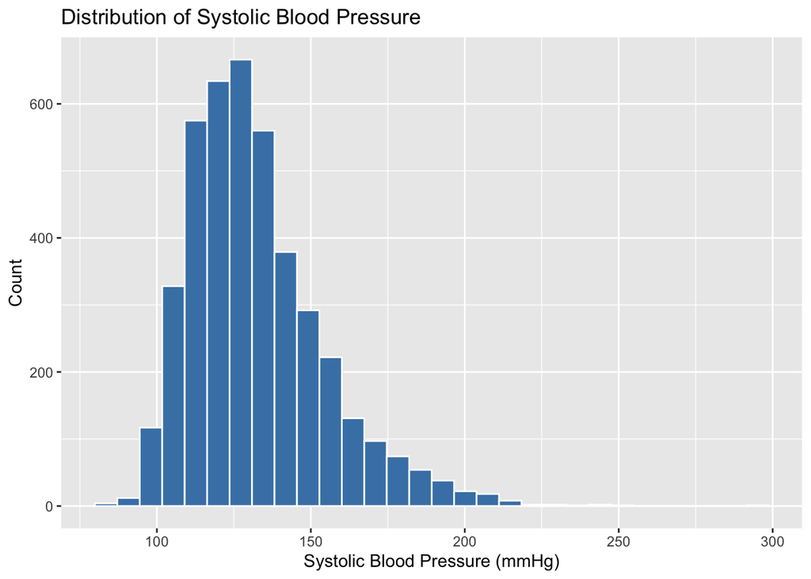

```r
ggplot(framingham, aes(x = sysBP)) +
  geom_histogram(fill = "steelblue", color = "white") +
  labs(x = "Systolic Blood Pressure (mmHg)", y = "Count",
       title = "Distribution of Systolic Blood Pressure")
```

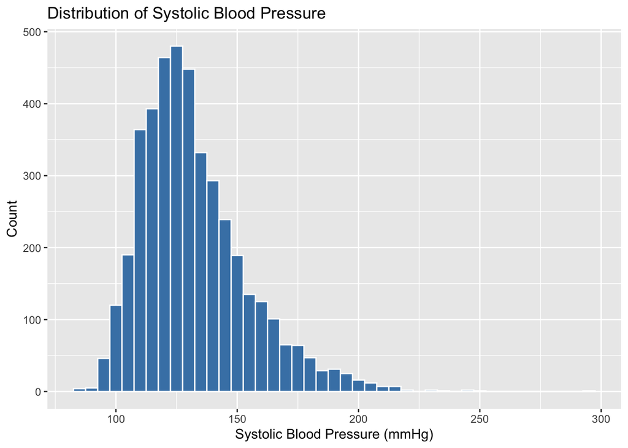

```r
ggplot(framingham, aes(x = sysBP)) +
  geom_histogram(binwidth = 5, fill = "steelblue", color = "white") +
  labs(x = "Systolic Blood Pressure (mmHg)", y = "Count",
       title = "Distribution of Systolic Blood Pressure")
```

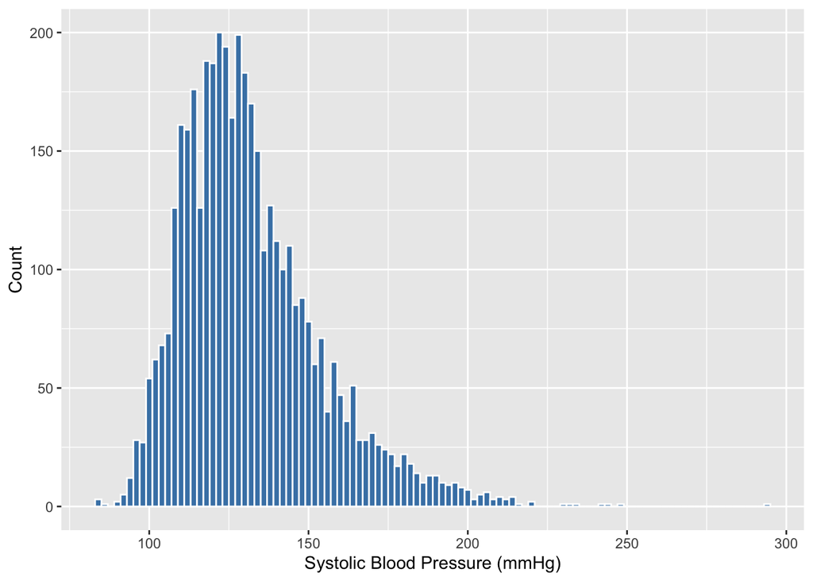

```r
# Narrower bins reveal more detail
ggplot(framingham, aes(x = sysBP)) +
  geom_histogram(binwidth = 2, fill = "steelblue", color = "white") +
  labs(x = "Systolic Blood Pressure (mmHg)", y = "Count")
```

The lower the binwidth, the more bumpy the histogram is going to look.

## 4.2 Continuous Variables: Density Plots

A density plot is a smoothed histogram. It is better than a histogram for overlaying multiple groups because lines are easier to compare than bars.

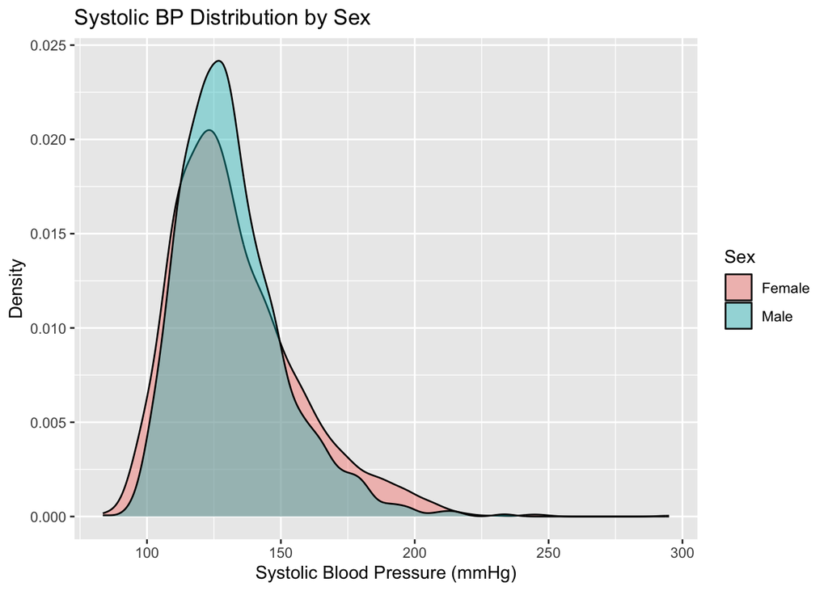

```r
ggplot(framingham, aes(x = sysBP, fill = male)) +
  # alpha will control how transparent the fill colors are.
  geom_density(alpha = 0.4) +
  labs(x = "Systolic Blood Pressure (mmHg)", y = "Density",
       fill = "Sex",
       title = "Systolic BP Distribution by Sex")
```

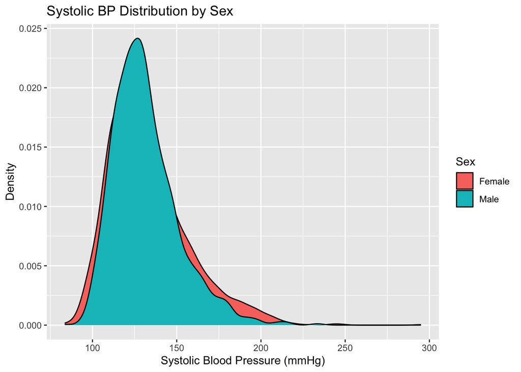

```r
ggplot(framingham, aes(x = sysBP, fill = male)) +
  # alpha will control how transparent the fill colors are.
  geom_density(alpha = 1) +
  labs(x = "Systolic Blood Pressure (mmHg)", y = "Density",
       fill = "Sex",
       title = "Systolic BP Distribution by Sex")
```

## 4.3 Categorical Variables: Bar Charts

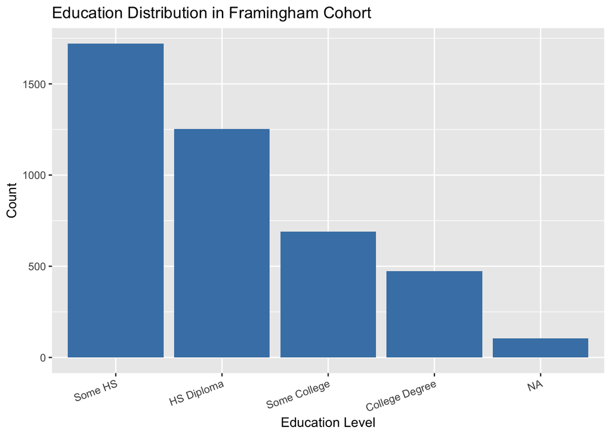

```r
ggplot(framingham, aes(x = education)) +
  geom_bar(fill = "steelblue") +
  labs(x = "Education Level", y = "Count",
       title = "Education Distribution in Framingham Cohort") +
  theme(axis.text.x = element_text(angle = 20, hjust = 1))
```

To plot proportions rather than counts, compute them first with `dplyr` and use `geom_col()`:

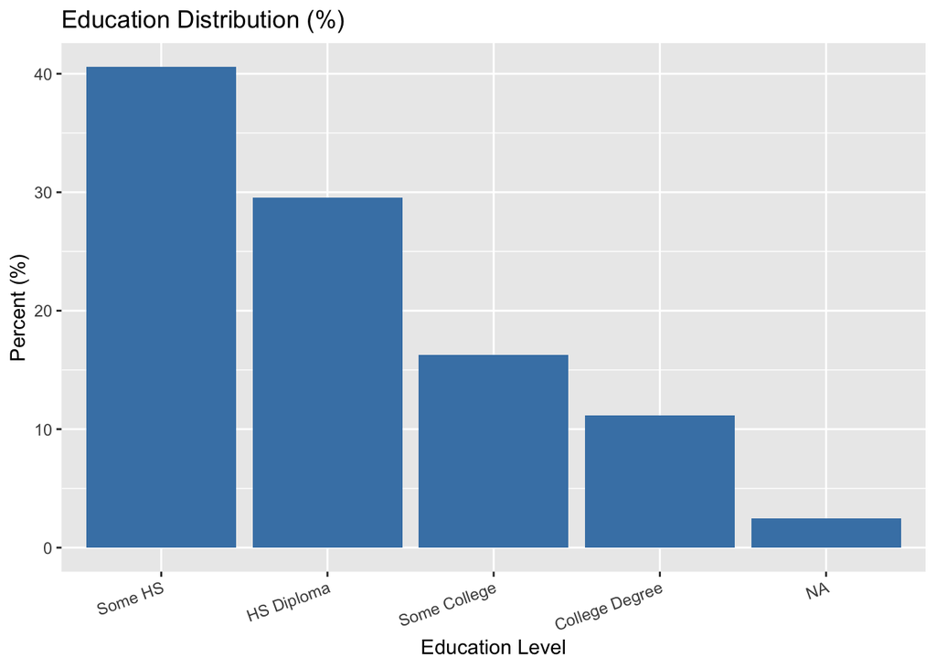

```r
framingham |>
  count(education) |>
  mutate(pct = n / sum(n) * 100) |>
  ggplot(aes(x = education, y = pct)) +
  geom_col(fill = "steelblue") +
  labs(x = "Education Level", y = "Percent (%)",
       title = "Education Distribution (%)") +
  theme(axis.text.x = element_text(angle = 20, hjust = 1))
```

# 5 Visualizing Covariation

## 5.1 Continuous + Categorical: Boxplots

Boxplots show the median, IQR, and outliers compactly. They are ideal for comparing a continuous variable across groups.

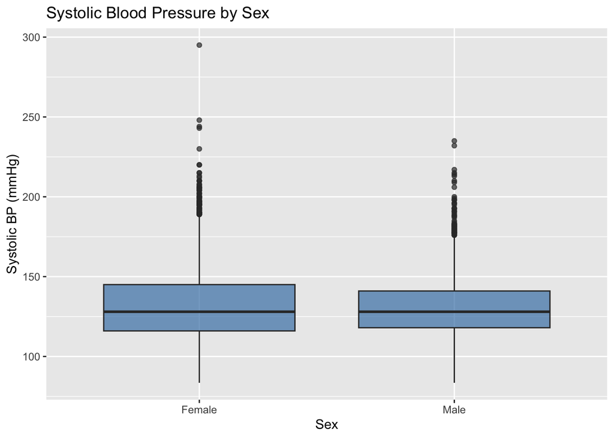

```r
ggplot(framingham, aes(x = male, y = sysBP)) +
  geom_boxplot(fill = "steelblue", alpha = 0.7) +
  labs(x = "Sex", y = "Systolic BP (mmHg)",
       title = "Systolic Blood Pressure by Sex")
```

When you have many groups, order them by the median to make comparisons easier:

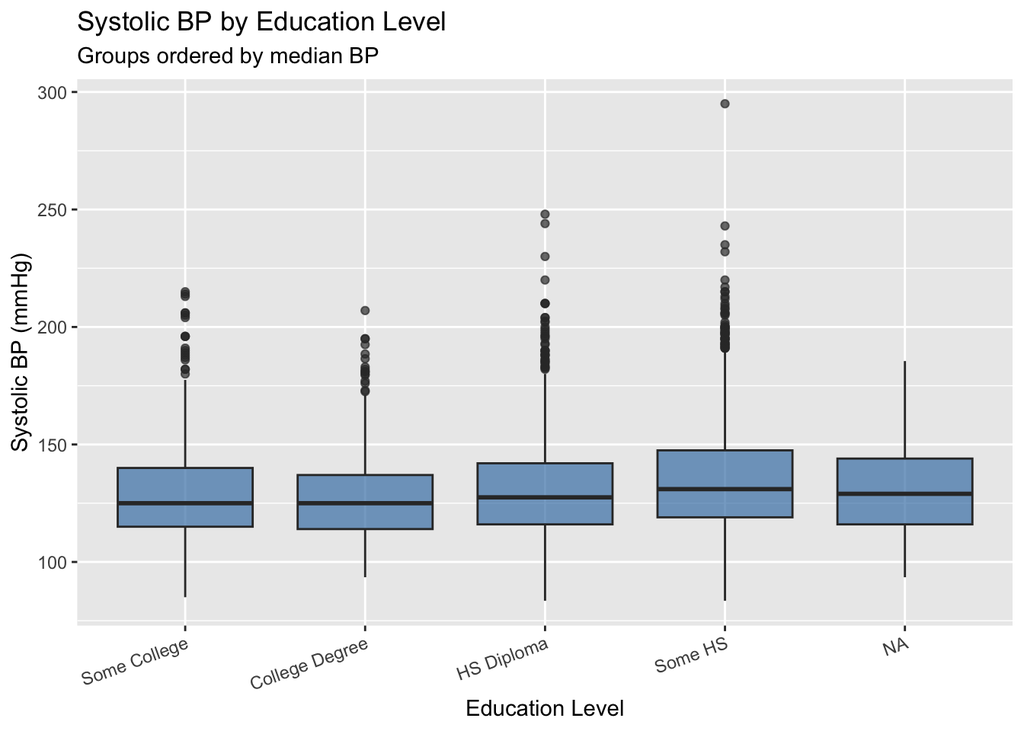

```r
ggplot(framingham, aes(x = reorder(education, sysBP, FUN = median),
                       y = sysBP)) +
  geom_boxplot(fill = "steelblue", alpha = 0.7) +
  labs(x = "Education Level",
       y = "Systolic BP (mmHg)",
       title = "Systolic BP by Education Level",
       subtitle = "Groups ordered by median BP") +
  theme(axis.text.x = element_text(angle = 20, hjust = 1))
```

## 5.2 Continuous + Categorical: Violin Plots

A violin plot shows the full distribution shape, not just the summary statistics. Combine with a boxplot overlay for the best of both:

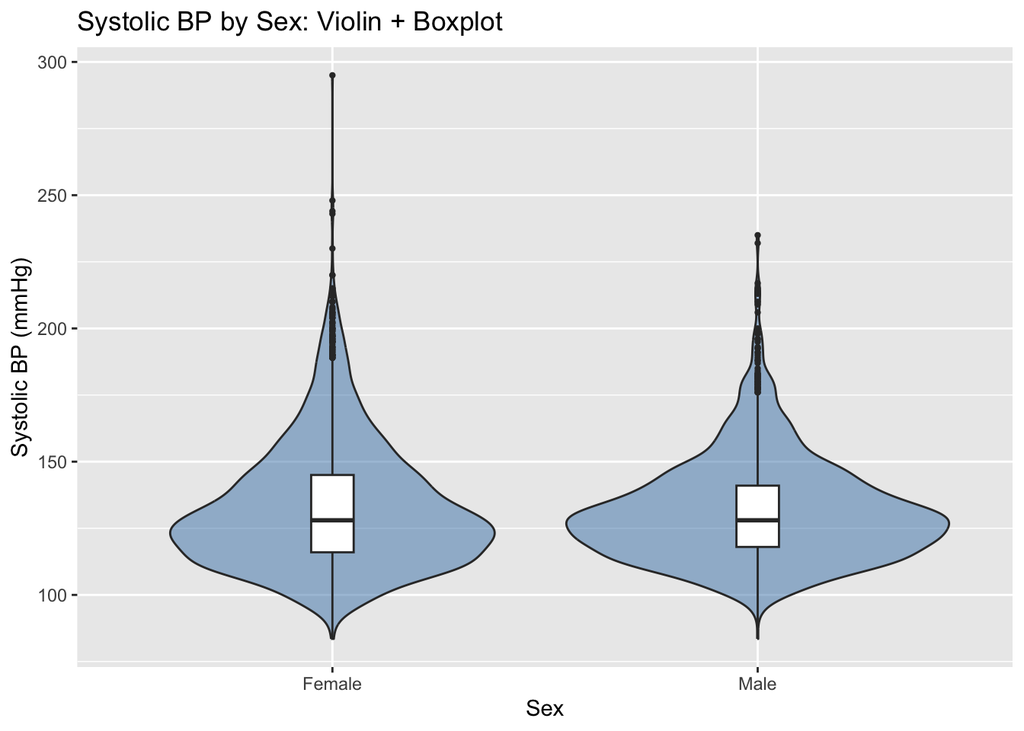

```r
ggplot(framingham, aes(x = male, y = sysBP)) +
  geom_violin(fill = "steelblue", alpha = 0.5) +
  geom_boxplot(width = 0.1, fill = "white", outlier.size = 0.8) +
  labs(x = "Sex", y = "Systolic BP (mmHg)",
       title = "Systolic BP by Sex: Violin + Boxplot")
```

## 5.3 Continuous + Categorical: Frequency Polygons

`geom_freqpoly()` overlays distributions as lines rather than bars.

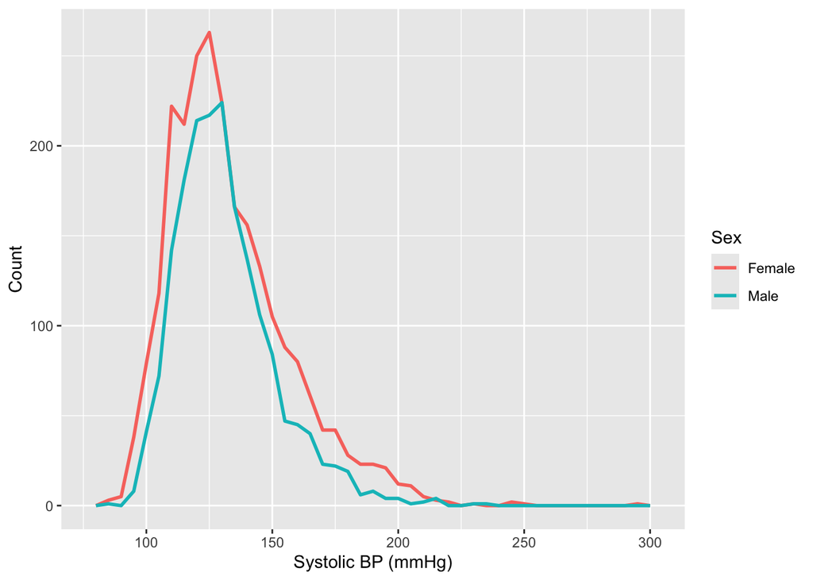

```r
ggplot(framingham, aes(x = sysBP, color = male)) +
  geom_freqpoly(binwidth = 5, linewidth = 1) +
  labs(x = "Systolic BP (mmHg)", y = "Count", color = "Sex")
```

When groups differ greatly in size, use `y = after_stat(density)` to standardize:

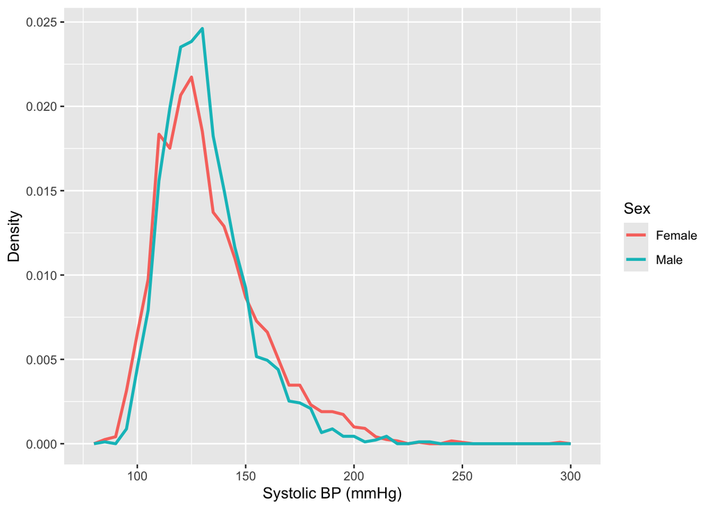

```r
# Density version -- better for comparing groups of unequal size
ggplot(framingham, aes(x = sysBP, y = after_stat(density), color = male)) +
  geom_freqpoly(binwidth = 5, linewidth = 1) +
  labs(x = "Systolic BP (mmHg)", y = "Density", color = "Sex")
```

## 5.4 Two Continuous Variables: Scatterplots

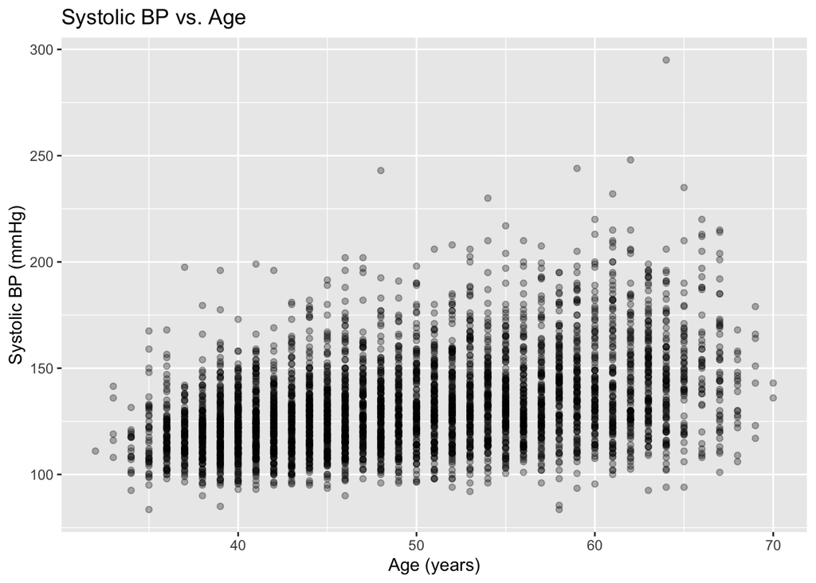

```r
ggplot(framingham, aes(x = age, y = sysBP)) +
  geom_point(alpha = 0.3) +
  labs(x = "Age (years)", y = "Systolic BP (mmHg)",
       title = "Systolic BP vs. Age")
```

Add a smooth trend line with `geom_smooth()`:

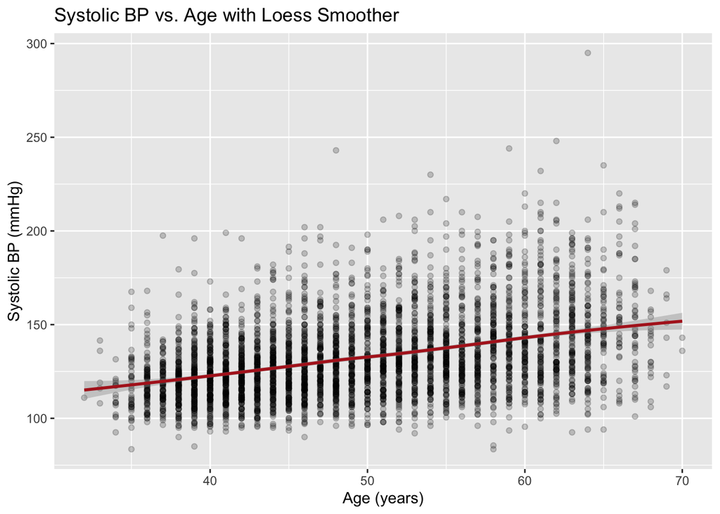

```r
ggplot(framingham, aes(x = age, y = sysBP)) +
  geom_point(alpha = 0.2) +
  # method = "loess" lines can show non-linear trends.
  geom_smooth(method = "loess", color = "firebrick", se = TRUE) +
  labs(x = "Age (years)", y = "Systolic BP (mmHg)",
       title = "Systolic BP vs. Age with Loess Smoother")
```

Map a third variable to color:

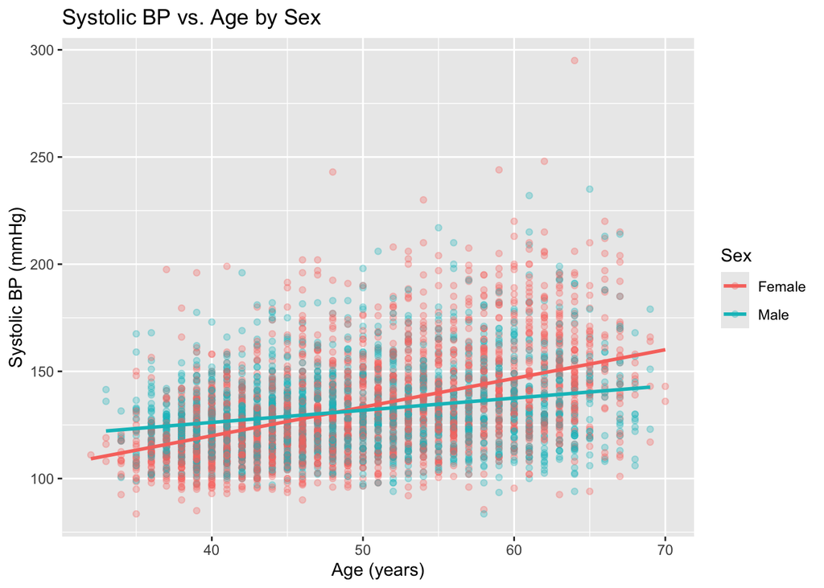

```r
ggplot(framingham, aes(x = age, y = sysBP, color = male)) +
  geom_point(alpha = 0.3) +
  # method = "lm" only shows linear trends.
  geom_smooth(method = "lm", se = FALSE) +
  labs(x = "Age (years)", y = "Systolic BP (mmHg)",
       color = "Sex",
       title = "Systolic BP vs. Age by Sex")
```

### 5.4.1 Log Transformations

When a variable is right-skewed, a log transform often reveals structure hidden in the raw scale. Use `scale_x_log10()` to keep the original axis labels:

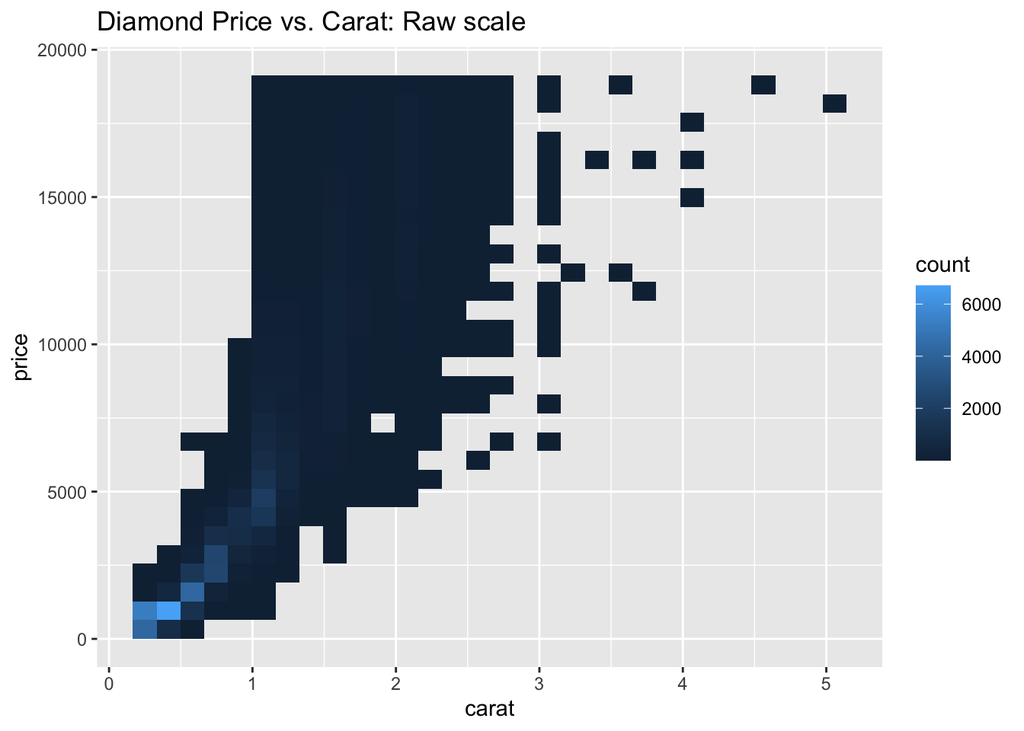

```r
ggplot(diamonds, aes(x = carat, y = price)) +
  geom_bin2d() +
  labs(title = "Diamond Price vs. Carat: Raw scale")
```

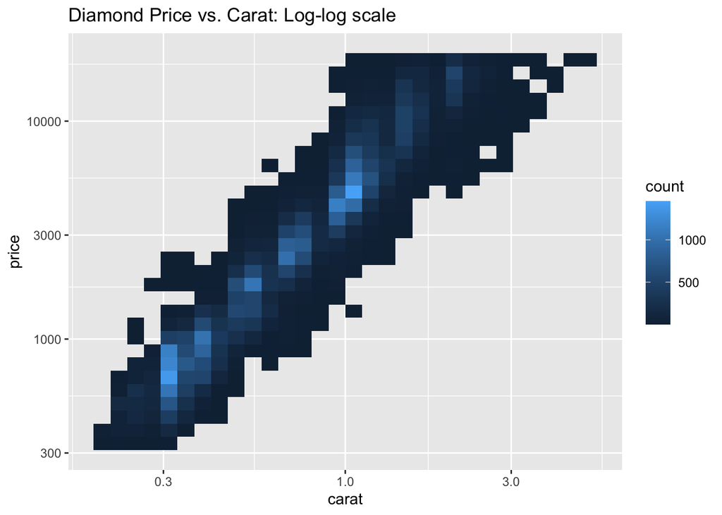

```r
ggplot(diamonds, aes(x = carat, y = price)) +
  geom_bin2d() +
  scale_x_log10() +
  scale_y_log10() +
  labs(title = "Diamond Price vs. Carat: Log-log scale")
```

### 5.4.2 Overplotting

Large datasets suffer from overplotting — points pile on top of each other and the density is invisible. Solutions:

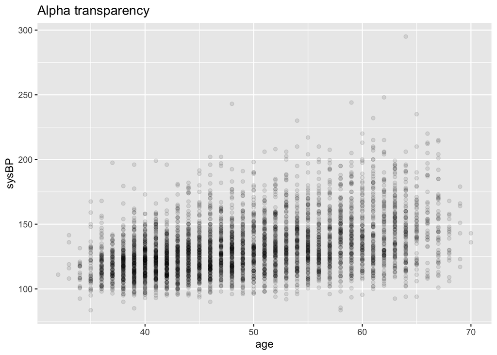

```r
# Alpha transparency
ggplot(framingham, aes(x = age, y = sysBP)) +
  geom_point(alpha = 0.1) +
  labs(title = "Alpha transparency")
```

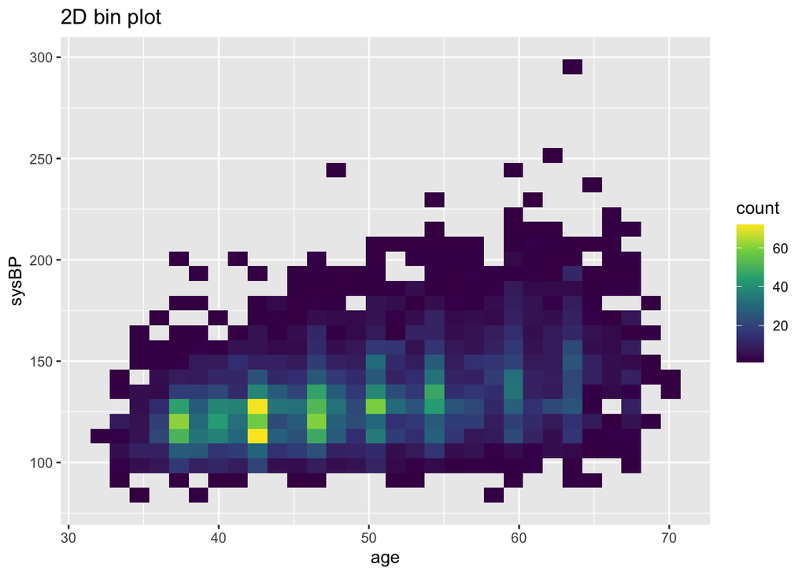

```r
# 2D bins
ggplot(framingham, aes(x = age, y = sysBP)) +
  geom_bin2d(bins = 30) +
  scale_fill_viridis_c() +
  labs(title = "2D bin plot")
```

# 6 Faceting

Faceting splits a plot into small multiples by a variable — often cleaner than color coding when there are many groups.

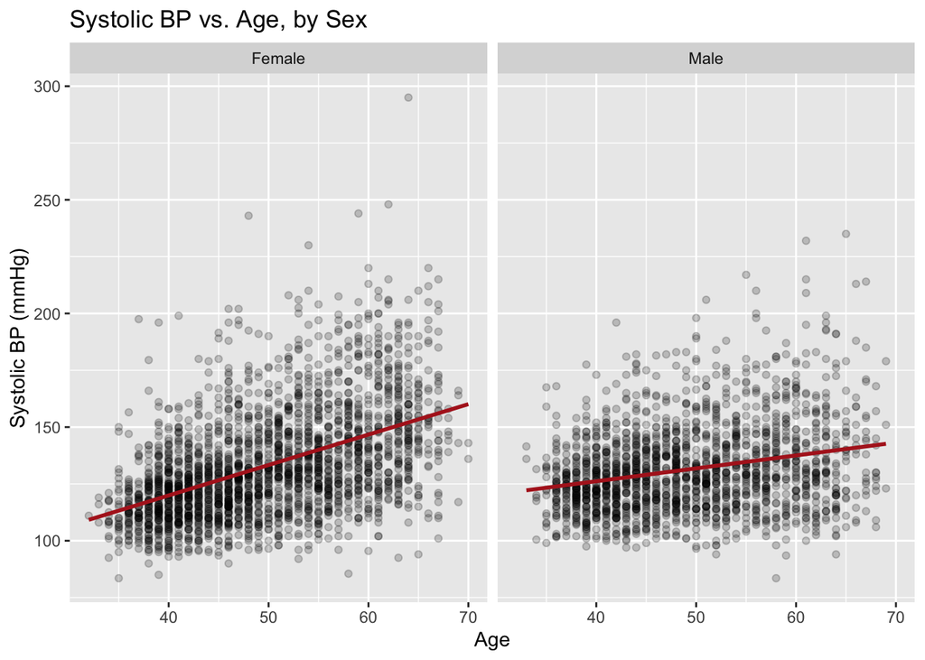

```r
ggplot(framingham, aes(x = age, y = sysBP)) +
  geom_point(alpha = 0.2) +
  geom_smooth(method = "lm", se = FALSE, color = "firebrick") +
  facet_wrap(~ male) +
  labs(x = "Age", y = "Systolic BP (mmHg)",
       title = "Systolic BP vs. Age, by Sex")
```

You can allow the x, y, or both scales to be unique across plots.

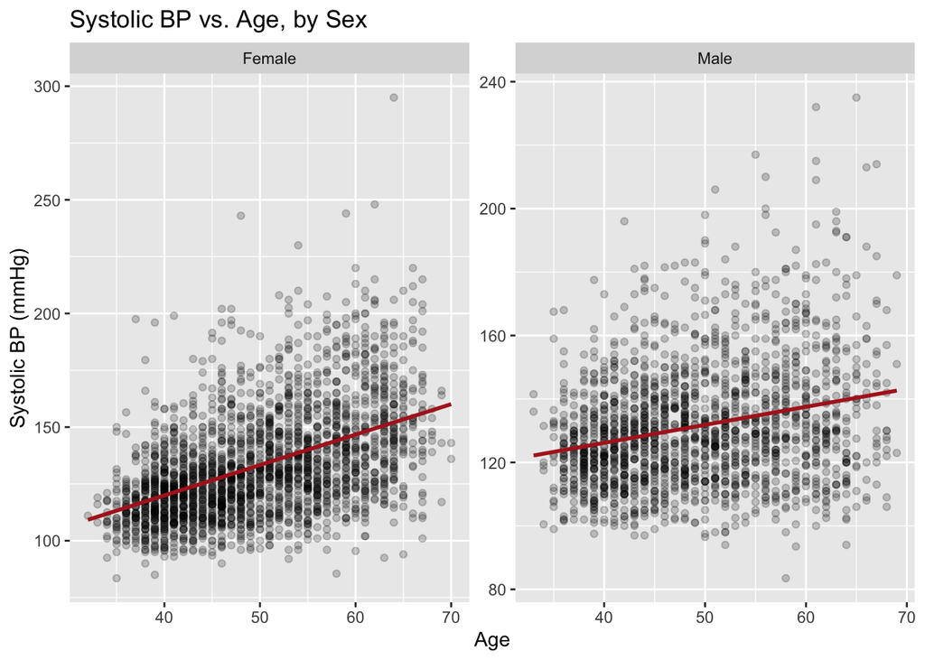

```r
ggplot(framingham, aes(x = age, y = sysBP)) +
  geom_point(alpha = 0.2) +
  geom_smooth(method = "lm", se = FALSE, color = "firebrick") +
  facet_wrap(~ male, scales = "free") +
  labs(x = "Age", y = "Systolic BP (mmHg)",
       title = "Systolic BP vs. Age, by Sex")
```

`facet_grid()` facets on two variables simultaneously:

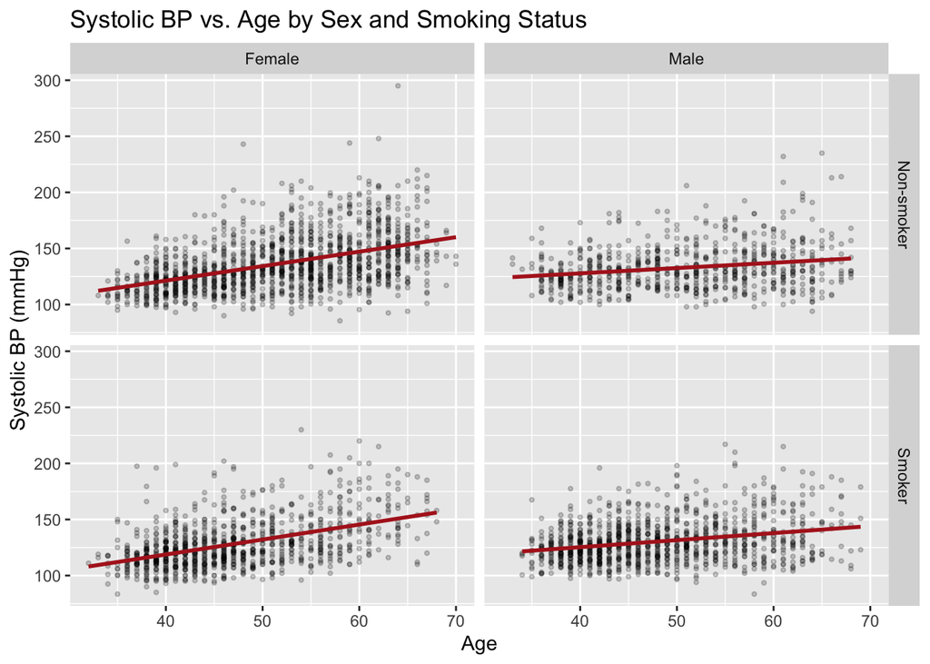

```r
ggplot(framingham, aes(x = age, y = sysBP)) +
  geom_point(alpha = 0.2, size = 0.8) +
  geom_smooth(method = "lm", se = FALSE, color = "firebrick") +
  facet_grid(currentSmoker ~ male) +
  labs(x = "Age", y = "Systolic BP (mmHg)",
       title = "Systolic BP vs. Age by Sex and Smoking Status")
```

You can do the same with `facet_wrap` but the labels are not as nice:

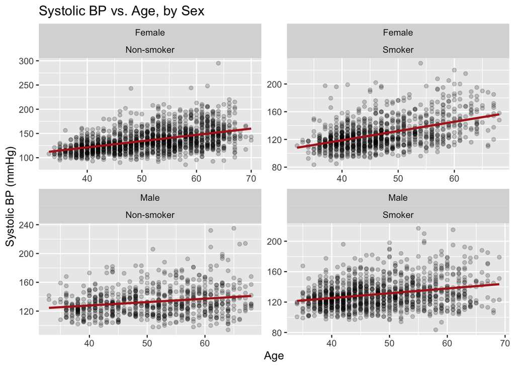

```r
ggplot(framingham, aes(x = age, y = sysBP)) +
  geom_point(alpha = 0.2) +
  geom_smooth(method = "lm", se = FALSE, color = "firebrick") +
  facet_wrap(~ male + currentSmoker, scales = "free") +
  labs(x = "Age", y = "Systolic BP (mmHg)",
       title = "Systolic BP vs. Age, by Sex")
```

# 7 Labels and Annotation

## 7.1 `labs()`: Titles, Axes, and Legends

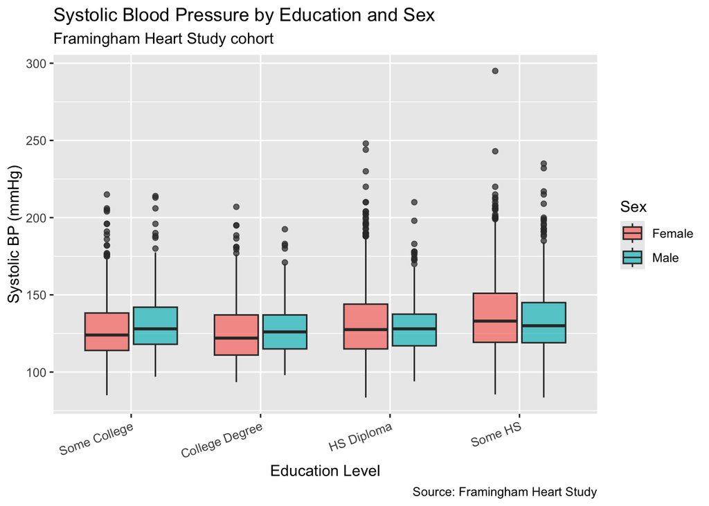

```r
framingham |>
  filter(!is.na(education)) |> # Removing those with NA for eductation (you could include)
  ggplot(aes(x = reorder(education, sysBP, FUN = median),
                         y = sysBP, fill = male)) +
  geom_boxplot(alpha = 0.7) +
  labs(
    title    = "Systolic Blood Pressure by Education and Sex",
    subtitle = "Framingham Heart Study cohort",
    caption  = "Source: Framingham Heart Study",
    x        = "Education Level",
    y        = "Systolic BP (mmHg)",
    fill     = "Sex"
  ) +
  theme(axis.text.x = element_text(angle = 20, hjust = 1))
```

## 7.2 `geom_text()` and `geom_label()`

Label individual points or groups directly on the plot. Here we label the car model with the best highway mileage in each class:

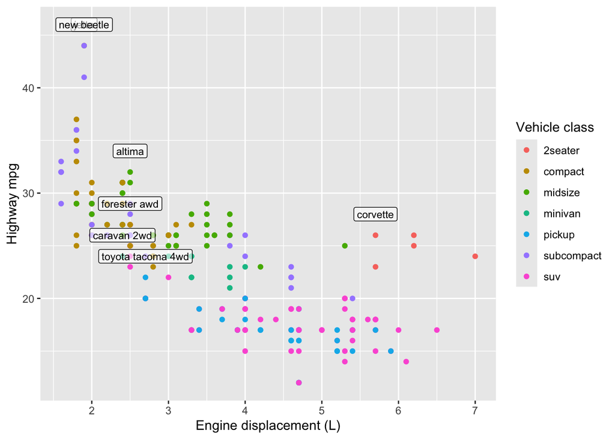

```r
best_in_class <- mpg |>
  group_by(class) |>
  filter(row_number(desc(hwy)) == 1)

ggplot(mpg, aes(displ, hwy)) +
  geom_point(aes(color = class)) +
  geom_label(aes(label = model), data = best_in_class,
             nudge_y = 2, alpha = 0.6, size = 3) +
  labs(x = "Engine displacement (L)", y = "Highway mpg",
       color = "Vehicle class")
```

For overlapping labels, use `ggrepel` which automatically repositions them:

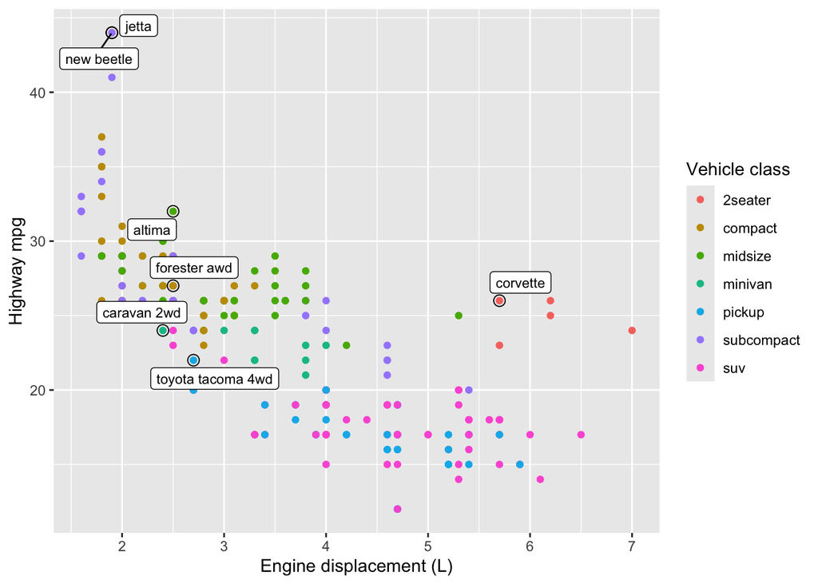

```r
# install.packages("ggrepel")
library(ggrepel)

ggplot(mpg, aes(displ, hwy)) +
  geom_point(aes(color = class)) +
  geom_point(size = 3, shape = 1, data = best_in_class) +
  geom_label_repel(aes(label = model), data = best_in_class, size = 3) +
  labs(x = "Engine displacement (L)", y = "Highway mpg",
       color = "Vehicle class")
```

## 7.3 Reference Lines

Add horizontal or vertical reference lines to mark thresholds:

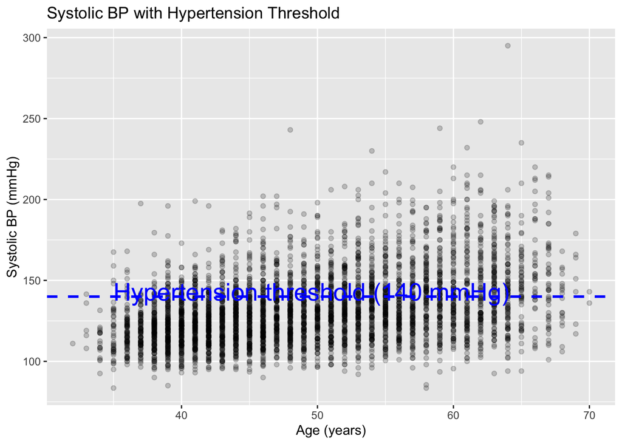

```r
ggplot(framingham, aes(x = age, y = sysBP)) +
  geom_point(alpha = 0.2) +
  geom_hline(yintercept = 140, color = "blue",
             linewidth = 1, linetype = "dashed") +
  annotate("text", x = 35, y = 143,
           label = "Hypertension threshold (140 mmHg)",
           color = "blue", hjust = 0, size = 7) +
  labs(x = "Age (years)", y = "Systolic BP (mmHg)",
       title = "Systolic BP with Hypertension Threshold")
```

# 8 Scales

Scales control how data values map to visual properties. `ggplot2` names them consistently: `scale_<aesthetic>_<type>()`.

## 8.1 Axis Breaks and Labels

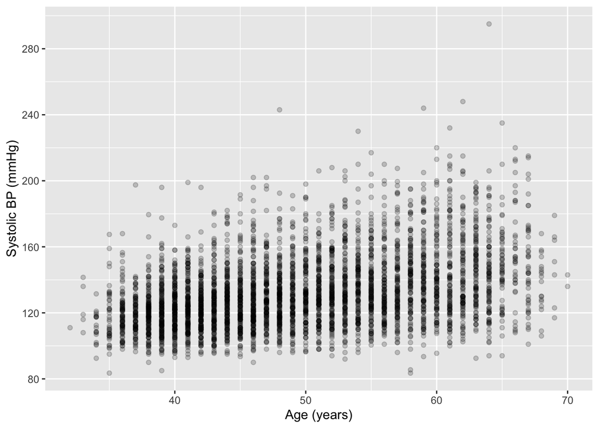

```r
ggplot(framingham, aes(x = age, y = sysBP)) +
  geom_point(alpha = 0.2) +
  scale_x_continuous(breaks = seq(30, 70, by = 10)) +
  scale_y_continuous(breaks = seq(80, 300, by = 40)) +
  labs(x = "Age (years)", y = "Systolic BP (mmHg)")
```

## 8.2 Color Scales

The default color palette is not always ideal — especially for color-blind readers. ColorBrewer palettes are designed for this:

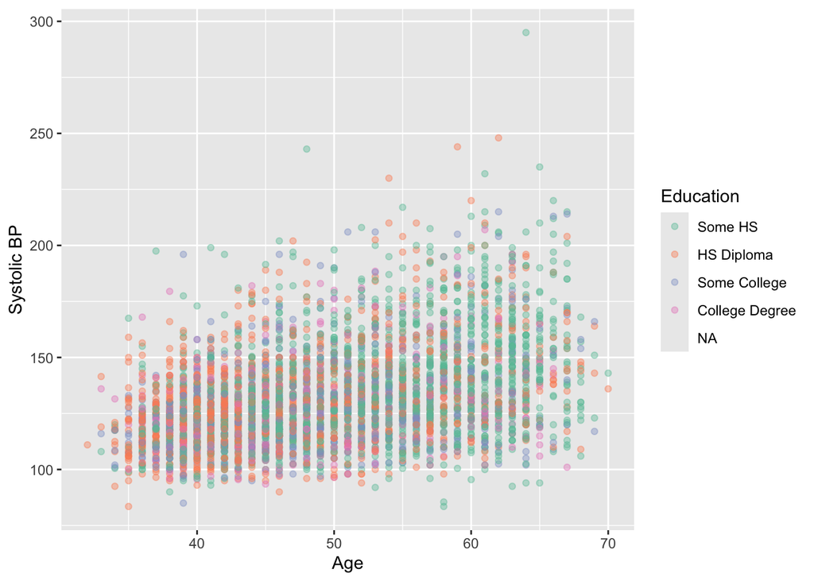

```r
ggplot(framingham, aes(x = age, y = sysBP, color = education)) +
  geom_point(alpha = 0.4) +
  scale_color_brewer(palette = "Set2") +
  labs(x = "Age", y = "Systolic BP", color = "Education")
```

For continuous color scales, use viridis which is both colorblind-friendly and perceptually uniform:

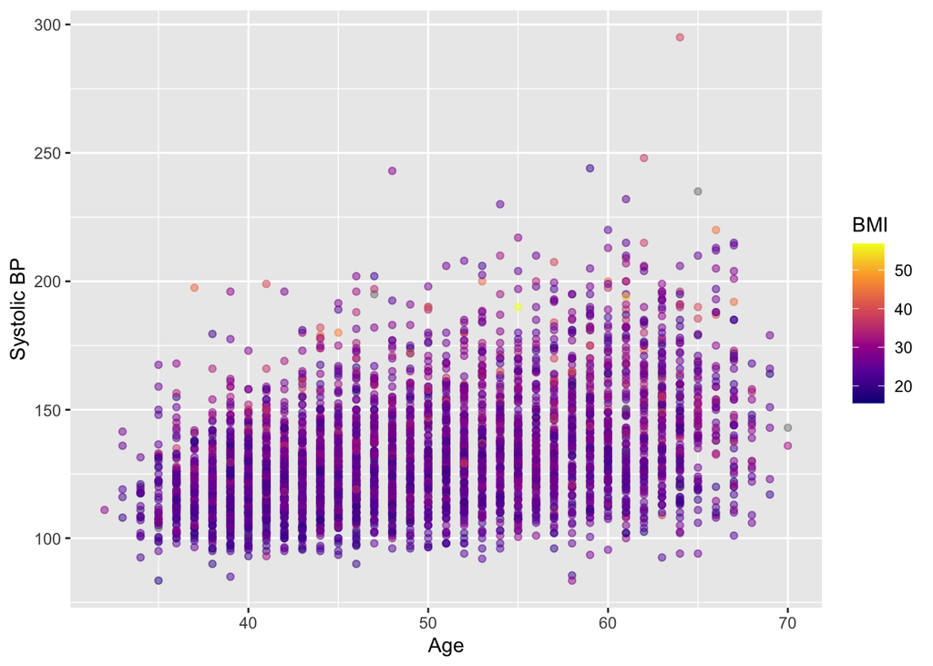

```r
ggplot(framingham, aes(x = age, y = sysBP, color = BMI)) +
  geom_point(alpha = 0.5) +
  scale_color_viridis_c(option = "plasma") +
  labs(x = "Age", y = "Systolic BP", color = "BMI")
```

For a diverging scale (e.g., positive/negative, above/below a midpoint):

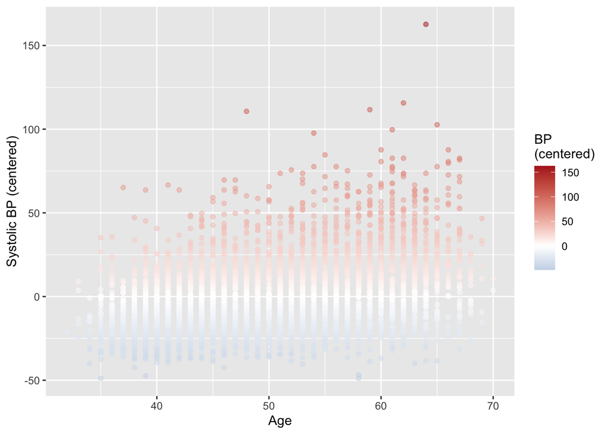

```r
framingham |>
  mutate(sysBP_centered = sysBP - mean(sysBP, na.rm = TRUE)) |>
  ggplot(aes(x = age, y = sysBP_centered, color = sysBP_centered)) +
  geom_point(alpha = 0.5) +
  scale_color_gradient2(low = "steelblue", mid = "white",
                        high = "firebrick", midpoint = 0) +
  labs(x = "Age", y = "Systolic BP (centered)", color = "BP\n(centered)")
```